# Contents

## 3.3 Interpretation of the performance of the best GBM model

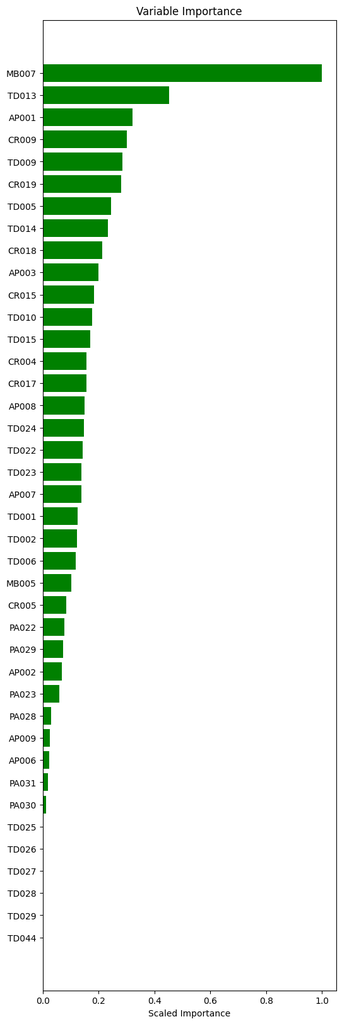

```python
# Visualize the result of the importance of the varibales
def VarImp(model_name):

    from sklearn.metrics import roc_curve,auc
    from sklearn.metrics import average_precision_score
    from sklearn.metrics import precision_recall_curve
    import matplotlib.pyplot as plt

    # plot the variable importance
    plt.rcdefaults()
    variables = model_name._model_json['output']['variable_importances']['variable']
    y_pos = np.arange(len(variables))
    fig, ax = plt.subplots(figsize = (6,len(variables)/2))
    scaled_importance = model_name._model_json['output']['variable_importances']['scaled_importance']
    ax.barh(y_pos,scaled_importance,align='center',color='green')
    ax.set_yticks(y_pos)
    ax.set_yticklabels(variables)
    ax.invert_yaxis()
    ax.set_xlabel('Scaled Importance')
    ax.set_title('Variable Importance')
    plt.show()

VarImp(GBM_mod4)
```

```python
# Prediction
predictions = GBM_mod4.predict(test_hex)
predictions.head()
test_scores = test_hex['loan_default'].cbind(predictions).as_data_frame()
test_scores.head()
```

```
gbm prediction progress: |███████████████████████████████████████████████████████| (done) 100%
```

|  | loan_default | predict |
| --- | --- | --- |
| 0 | 0 | 0.337608 |
| 1 | 0 | 0.060054 |
| 2 | 0 | 0.051457 |
| 3 | 0 | 0.324240 |
| 4 | 0 | 0.184411 |

```
gbm prediction progress: |███████████████████████████████████████████████████████| (done) 100%

   * ROC curve: The ROC curve plots the true positive rate vs. the false rositive sate

	  * The area under the curve (AUC): A value between 0.5 (random) and 1.0 (perfect), measuring the prediction accuracy

   * Recall (R) = The number of true positives / (the number of true positives + the number of false negatives)
```

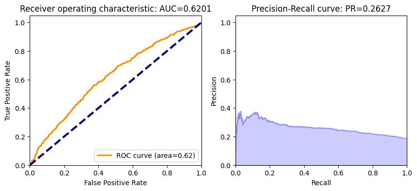

```python
def ROC_AUC(my_result,df,target):
    from sklearn.metrics import roc_curve,auc
    from sklearn.metrics import average_precision_score
    from sklearn.metrics import precision_recall_curve
    import matplotlib.pyplot as plt

    # ROC
    y_actual = df[target].as_data_frame()
    y_pred = my_result.predict(df).as_data_frame()
    fpr = list()
    tpr = list()
    roc_auc = list()
    fpr,tpr,_ = roc_curve(y_actual,y_pred)
    roc_auc = auc(fpr,tpr)

    # Precision-Recall
    average_precision = average_precision_score(y_actual,y_pred)

    print('')
    print('   * ROC curve: The ROC curve plots the true positive rate vs. the false rositive sate')
    print('')
    print('	  * The area under the curve (AUC): A value between 0.5 (random) and 1.0 (perfect), measuring the prediction accuracy')
    print('')
    print('   * Recall (R) = The number of true positives / (the number of true positives + the number of false negatives)')
    print('')

    # plotting
    plt.figure(figsize=(10,4))

    # ROC
    plt.subplot(1,2,1)
    plt.plot(fpr,tpr,color='darkorange',lw=2,label='ROC curve (area=%0.2f)' % roc_auc)
    plt.plot([0,1],[0,1],color='navy',lw=3,linestyle='--')
    plt.xlim([0.0,1.0])
    plt.ylim([0.0,1.05])
    plt.xlabel('False Positive Rate')
    plt.ylabel('True Positive Rate')
    plt.title('Receiver operating characteristic: AUC={0:0.4f}'.format(roc_auc))
    plt.legend(loc='lower right')

    # Precision-Recall
    plt.subplot(1,2,2)
    precision,recall,_ = precision_recall_curve(y_actual,y_pred)
    plt.step(recall,precision,color='b',alpha=0.2,where='post')
    plt.fill_between(recall,precision,step='post',alpha=0.2,color='b')
    plt.xlabel('Recall')
    plt.ylabel('Precision')
    plt.ylim([0.0,1.05])
    plt.xlim([0.0,1.0])
    plt.title('Precision-Recall curve: PR={0:0.4f}'.format(average_precision))
    plt.show()

ROC_AUC(GBM_mod4,test_hex,'loan_default')
```

```python
def createGains(model):
    predictions = model.predict(test_hex)
    test_scores = test_hex['loan_default'].cbind(predictions).as_data_frame()

    #sort on prediction (descending), add id, and decile for groups containing 1/10 of datapoints
    test_scores = test_scores.sort_values(by='predict',ascending=False)
    test_scores['row_id'] = range(0,0+len(test_scores))
    test_scores['decile'] = ( test_scores['row_id'] / (len(test_scores)/10) ).astype(int)
    #see count by decile
    test_scores.loc[test_scores['decile'] == 10]=9
    test_scores['decile'].value_counts()

    #create gains table
    gains = test_scores.groupby('decile')['loan_default'].agg(['count','sum'])
    gains.columns = ['count','actual']
    gains

    #add features to gains table
    gains['non_actual'] = gains['count'] - gains['actual']
    gains['cum_count'] = gains['count'].cumsum()
    gains['cum_actual'] = gains['actual'].cumsum()
    gains['cum_non_actual'] = gains['non_actual'].cumsum()
    gains['percent_cum_actual'] = (gains['cum_actual'] / np.max(gains['cum_actual'])).round(2)
    gains['percent_cum_non_actual'] = (gains['cum_non_actual'] / np.max(gains['cum_non_actual'])).round(2)
    gains['if_random'] = np.max(gains['cum_actual']) /10
    gains['if_random'] = gains['if_random'].cumsum()
    gains['lift'] = (gains['cum_actual'] / gains['if_random']).round(2)
    gains['K_S'] = np.abs( gains['percent_cum_actual'] -  gains['percent_cum_non_actual'] ) * 100
    gains['gain']=(gains['cum_actual']/gains['cum_count']*100).round(2)
    gains = pd.DataFrame(gains)
    return(gains)

createGains(GBM_mod4)
```

```
gbm prediction progress: |███████████████████████████████████████████████████████| (done) 100%
```

| decile | count | actual | non_actual | cum_count | cum_actual | cum_non_actual | percent_cum_actual | percent_cum_non_actual | if_random | lift | K_S | gain |
| --- | --- | --- | --- | --- | --- | --- | --- | --- | --- | --- | --- | --- |
| 0 | 320 | 105 | 215 | 320 | 105 | 215 | 0.18 | 0.08 | 60.0 | 1.75 | 10.0 | 32.81 |
| 1 | 320 | 75 | 245 | 640 | 180 | 460 | 0.30 | 0.18 | 120.0 | 1.50 | 12.0 | 28.12 |
| 2 | 320 | 76 | 244 | 960 | 256 | 704 | 0.43 | 0.27 | 180.0 | 1.42 | 16.0 | 26.67 |
| 3 | 320 | 74 | 246 | 1280 | 330 | 950 | 0.55 | 0.37 | 240.0 | 1.38 | 18.0 | 25.78 |
| 4 | 320 | 58 | 262 | 1600 | 388 | 1212 | 0.65 | 0.47 | 300.0 | 1.29 | 18.0 | 24.25 |
| 5 | 320 | 50 | 270 | 1920 | 438 | 1482 | 0.73 | 0.57 | 360.0 | 1.22 | 16.0 | 22.81 |
| 6 | 320 | 49 | 271 | 2240 | 487 | 1753 | 0.81 | 0.67 | 420.0 | 1.16 | 14.0 | 21.74 |
| 7 | 320 | 44 | 276 | 2560 | 531 | 2029 | 0.88 | 0.78 | 480.0 | 1.11 | 10.0 | 20.74 |
| 8 | 320 | 39 | 281 | 2880 | 570 | 2310 | 0.95 | 0.89 | 540.0 | 1.06 | 6.0 | 19.79 |
| 9 | 320 | 30 | 290 | 3200 | 600 | 2600 | 1.00 | 1.00 | 600.0 | 1.00 | 0.0 | 18.75 |

### **3.2.1 Gains Table**

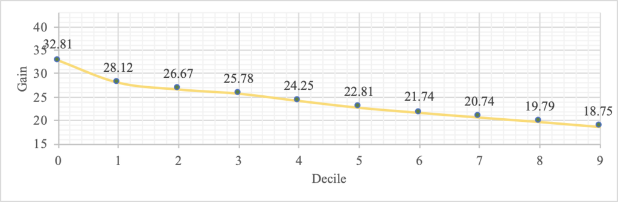

The purposes of gains table is to help analyst **select the model with better performance**, and **decide the segments should be focused on**.

According to the results, combining the mortgage business insight, there will be 32.81% (0.3281 * 320 = 105) customer in **decile 0** are bad loan applicants.

(*cum_actual* refers to the cumulative number of people who are actually unable to repay the loan.)

### **3.2.2 Lift**

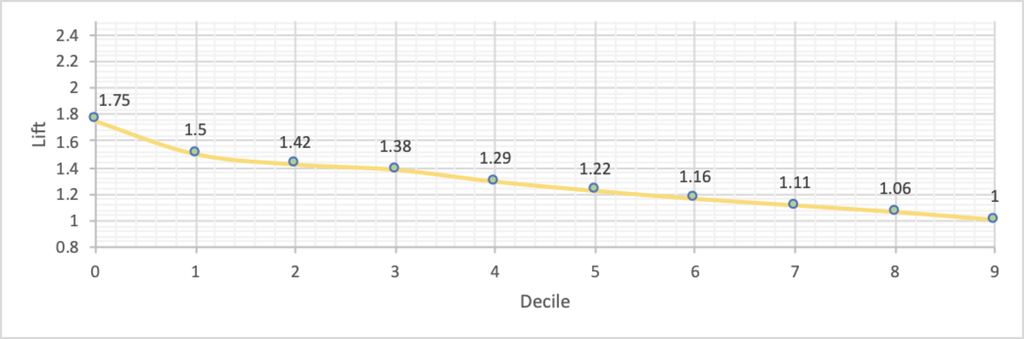

lift = cum_actual / if_random, which shows how much the bank can avoid bad applicants compared to banks randomly granting loans to customers.

### **3.2.3 Kolmogorov-Smirnov (K-S)**

K-S = |Cumultative % good — Cumulative % bad|, which measures the degree of separation between the distributions of the good and bad applicants.

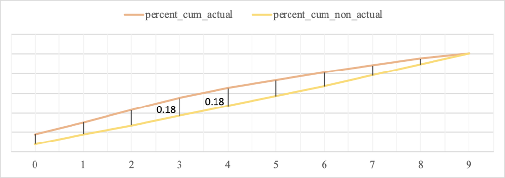

Frist of all, the K-S value for each deciles is not all 0, therefore the model effective to separate bad applicants from all customers. According to the figure above, I also find that the K-S values of Decile 3 and 4 reach to the maximum value of 0.18. In other words according to the results of K-S, the bank should **avoid applicants located through Decile 0 to Decile 3 or 4.**

### 3.2.4 ROC and PR Curves

```
gbm prediction progress: |███████████████████████████████████████████████████████| (done) 100%

   * ROC curve: The ROC curve plots the true positive rate vs. the false rositive sate

	  * The area under the curve (AUC): A value between 0.5 (random) and 1.0 (perfect), measuring the prediction accuracy

   * Recall (R) = The number of true positives / (the number of true positives + the number of false negatives)
```

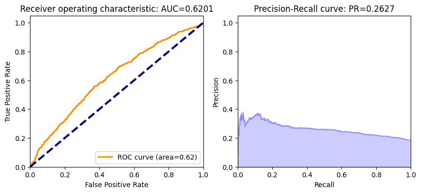

```python
ROC_AUC(GBM_mod4,test_hex,'loan_default')
```

**`Interpretation:`**

**Receiver operating characteristic (ROC) curve** visualizes the accuracy of predictions for a whole range of cutoff values. The AUC value is 0.62 which means the performance of the model is **poor**.

**Precision-Recall (PR) curves**, on the other hand, is more informative than ROC when dealing with highly skewed datasets. Since the value of average precision for the PR curve is only 0.2627, the dataset is **skewed and needed to be balanced.**

# 4. Deep Learning

```python
from h2o.estimators.deeplearning import H2ODeepLearningEstimator
DL_modl = H2ODeepLearningEstimator(
    distribution="tweedie",
    activation="RectifierWithDropout",
    hidden=[32,32,32], # Modify 1 [32], [32,32], [32,32,32],[64],[100],[100,100], [100,100,100]
    input_dropout_ratio=0.2,
    sparse=True,
    l1=1e-5,
    epochs=10) # Modify 2 [2,5,10]

DL_modl.train(
    x=predictors,
    y=target,
    training_frame=train_hex,
    validation_frame=test_hex)

DL_actual_predict = actual_predict(DL_modl,test_hex,target)
DL_roc_auc_value = roc_auc_score(DL_actual_predict['actual'],
                    DL_actual_predict['pred'])
DL_roc_auc_value
```

```
deeplearning Model Build progress: |
```

```
█████████████████████████████████████████████| (done) 100%
deeplearning prediction progress: |██████████████████████████████████████████████| (done) 100%
```

```
0.6277589743589743
```

## 4.1 Modify hyper-parameters

### 4.1.1 Hidden layers

[32], [32,32], [32,32,32],[64],[100],[100,100], [100,100,100]

```python
from h2o.estimators.deeplearning import H2ODeepLearningEstimator
DL_mod2 = H2ODeepLearningEstimator(
    distribution="tweedie",
    activation="RectifierWithDropout",
    # hidden = [100] has the best performance where ROC = 0.6379237179487179
    hidden=[100], # Modify 1 [32], [32,32], [32,32,32],[64],[100],[100,100], [100,100,100]
    input_dropout_ratio=0.2,
    sparse=True,
    l1=1e-5,
    epochs=10) # Modify 2 [2,5,10]

DL_mod2.train(
    x=predictors,
    y=target,
    training_frame=train_hex,
    validation_frame=test_hex)

DL_actual_predict = actual_predict(DL_mod2,test_hex,target)
DL_roc_auc_value = roc_auc_score(DL_actual_predict['actual'],
                    DL_actual_predict['pred'])
DL_roc_auc_value
```

```
deeplearning Model Build progress: |
```

```
█████████████████████████████████████████████| (done) 100%
deeplearning prediction progress: |██████████████████████████████████████████████| (done) 100%
```

```
0.6379237179487179
```

### 4.1.2 Epochs [2,5,10]

```python
from h2o.estimators.deeplearning import H2ODeepLearningEstimator
DL_mod3 = H2ODeepLearningEstimator(
    distribution="tweedie",
    activation="RectifierWithDropout",
    # hidden = [100], and epochs = 8 has the best performance where ROC = 0.639248076923077
    hidden=[100], # Modify 1 [32], [32,32], [32,32,32],[64],[100],[100,100], [100,100,100]
    input_dropout_ratio=0.2,
    sparse=True,
    l1=1e-5,
    epochs=10) # Modify 2 [2,5,7,8,10,12]

DL_mod3.train(
    x=predictors,
    y=target,
    training_frame=train_hex,
    validation_frame=test_hex)

DL_actual_predict = actual_predict(DL_mod3,test_hex,target)
DL_roc_auc_value = roc_auc_score(DL_actual_predict['actual'],
                    DL_actual_predict['pred'])
DL_roc_auc_value
```

```
deeplearning Model Build progress: |
```

```
█████████████████████████████████████████████| (done) 100%
deeplearning prediction progress: |██████████████████████████████████████████████| (done) 100%
```

```
0.639248076923077
```

## 4.2 Interpretation of the performance of the best DL model

```python
createGains(DL_mod3)
```

```
deeplearning prediction progress: |██████████████████████████████████████████████| (done) 100%
```

| decile | count | actual | non_actual | cum_count | cum_actual | cum_non_actual | percent_cum_actual | percent_cum_non_actual | if_random | lift | K_S | gain |
| --- | --- | --- | --- | --- | --- | --- | --- | --- | --- | --- | --- | --- |
| 0 | 320 | 103 | 217 | 320 | 103 | 217 | 0.17 | 0.08 | 60.0 | 1.72 | 9.0 | 32.19 |
| 1 | 320 | 100 | 220 | 640 | 203 | 437 | 0.34 | 0.17 | 120.0 | 1.69 | 17.0 | 31.72 |
| 2 | 320 | 70 | 250 | 960 | 273 | 687 | 0.46 | 0.26 | 180.0 | 1.52 | 20.0 | 28.44 |
| 3 | 320 | 70 | 250 | 1280 | 343 | 937 | 0.57 | 0.36 | 240.0 | 1.43 | 21.0 | 26.80 |
| 4 | 320 | 51 | 269 | 1600 | 394 | 1206 | 0.66 | 0.46 | 300.0 | 1.31 | 20.0 | 24.62 |
| 5 | 320 | 54 | 266 | 1920 | 448 | 1472 | 0.75 | 0.57 | 360.0 | 1.24 | 18.0 | 23.33 |
| 6 | 320 | 47 | 273 | 2240 | 495 | 1745 | 0.82 | 0.67 | 420.0 | 1.18 | 15.0 | 22.10 |
| 7 | 320 | 53 | 267 | 2560 | 548 | 2012 | 0.91 | 0.77 | 480.0 | 1.14 | 14.0 | 21.41 |
| 8 | 320 | 28 | 292 | 2880 | 576 | 2304 | 0.96 | 0.89 | 540.0 | 1.07 | 7.0 | 20.00 |
| 9 | 320 | 24 | 296 | 3200 | 600 | 2600 | 1.00 | 1.00 | 600.0 | 1.00 | 0.0 | 18.75 |

### 4.2.1 Gains Table

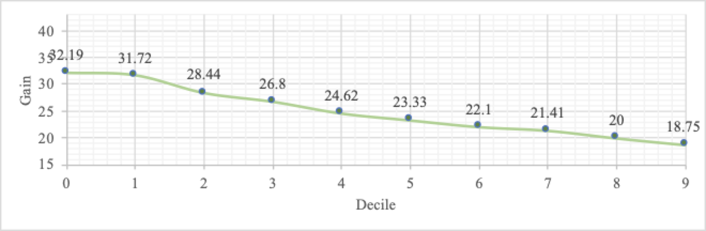

According to the results, combining the mortgage business insight, there will be 32.19% (0.3219 * 320 = 103) customer in decile 0 are bad loan applicants.

Comparison with the results before the adjustment shows that **the adjusted model identifies more frauds in the first few deciles.**

### 4.2.2 Lift

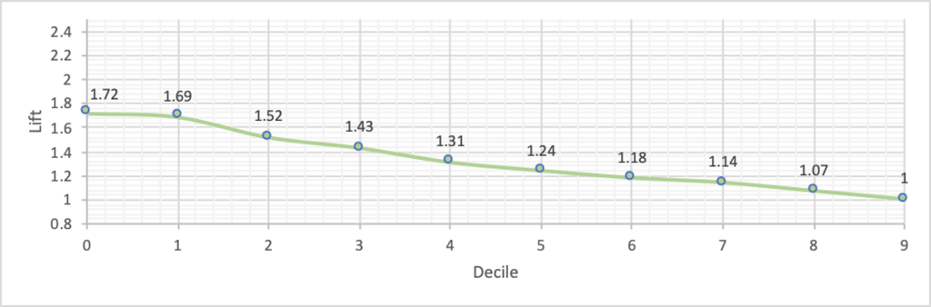

lift = cum_actual / if_random, which shows how much the bank can avoid bad applicants compared to banks randomly granting loans to customers.

**The suggestion is more close to the suggestion from gains table than the before model.**

### 4.2.3 K-S

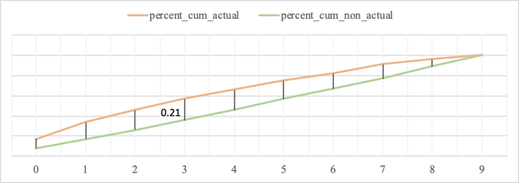

Frist of all, the K-S value for each deciles is not all 0, therefore the model effectively separate bad applicants from all customers. According to the figure above, I also find that the K-S value of Decile 3 reach to the maximum value of 0.21. In other words according to the results of K-S, the bank should avoid applicants located through Decile 0 to Decile 3.

### 4.2.4 ROC and PR Curves

```
deeplearning prediction progress: |██████████████████████████████████████████████| (done) 100%

   * ROC curve: The ROC curve plots the true positive rate vs. the false rositive sate

	  * The area under the curve (AUC): A value between 0.5 (random) and 1.0 (perfect), measuring the prediction accuracy

   * Recall (R) = The number of true positives / (the number of true positives + the number of false negatives)
```

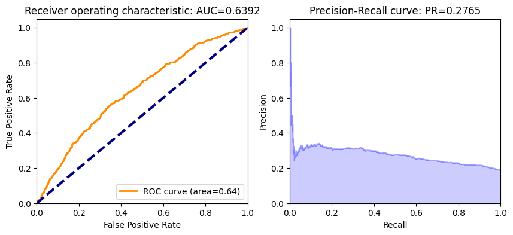

```python
ROC_AUC(DL_mod3,test_hex,'loan_default')
```

**ROC** curve visualizes the accuracy of predictions for a whole range of cutoff values. The AUC value is 0.64 which means the performance of the model is **poor**.

**PR** curves, on the other hand, is more informative than ROC when dealing with highly skewed datasets. Since the value of average precision for the PR curve is only 0.2765, the dataset is **skewed** and needed to be balanced.

# Summary

Taking all the above analysis into account, I think if the bank wants to expand its loan business, it can consider applicants from **Decile 5 to Decile 9**; if the bank wants to recover most of the loans securely and ensure profitability, it should consider applicants from **Decile 6 to Decile 9.**

And by comparing the two models with the best ROC performance under GBM and DL, it is easy to see that the results obtained are very similar, with **DL slightly better than GBM.**